# Risk Factor Analysis

## Outcome Variable

**Outcome Variable:** ever_stunted

## Predictor Variables

**Intervention Variable:** perdiar24

**Adjustment Set:**

unadjusted

## Stratifying Variables

The analysis was stratified on these variable(s):

- agecat
- studyid
- country

## Data Summary

| agecat | studyid | country | perdiar24 | ever_stunted | n_cell | n |
| --- | --- | --- | --- | --- | --- | --- |
| 0-6 months | ki0047075b-MAL-ED | BANGLADESH | Q1 | 0 | 23 | 265 |
| 0-6 months | ki0047075b-MAL-ED | BANGLADESH | Q1 | 1 | 7 | 265 |
| 0-6 months | ki0047075b-MAL-ED | BANGLADESH | Q2 | 0 | 42 | 265 |
| 0-6 months | ki0047075b-MAL-ED | BANGLADESH | Q2 | 1 | 10 | 265 |
| 0-6 months | ki0047075b-MAL-ED | BANGLADESH | Q3 | 0 | 89 | 265 |
| 0-6 months | ki0047075b-MAL-ED | BANGLADESH | Q3 | 1 | 10 | 265 |
| 0-6 months | ki0047075b-MAL-ED | BANGLADESH | Q4 | 0 | 63 | 265 |
| 0-6 months | ki0047075b-MAL-ED | BANGLADESH | Q4 | 1 | 21 | 265 |
| 0-6 months | ki0047075b-MAL-ED | BRAZIL | Q1 | 0 | 135 | 233 |
| 0-6 months | ki0047075b-MAL-ED | BRAZIL | Q1 | 1 | 13 | 233 |
| 0-6 months | ki0047075b-MAL-ED | BRAZIL | Q2 | 0 | 59 | 233 |
| 0-6 months | ki0047075b-MAL-ED | BRAZIL | Q2 | 1 | 11 | 233 |
| 0-6 months | ki0047075b-MAL-ED | BRAZIL | Q3 | 0 | 13 | 233 |
| 0-6 months | ki0047075b-MAL-ED | BRAZIL | Q3 | 1 | 1 | 233 |
| 0-6 months | ki0047075b-MAL-ED | BRAZIL | Q4 | 0 | 1 | 233 |
| 0-6 months | ki0047075b-MAL-ED | BRAZIL | Q4 | 1 | 0 | 233 |
| 0-6 months | ki0047075b-MAL-ED | INDIA | Q1 | 0 | 30 | 251 |
| 0-6 months | ki0047075b-MAL-ED | INDIA | Q1 | 1 | 6 | 251 |
| 0-6 months | ki0047075b-MAL-ED | INDIA | Q2 | 0 | 67 | 251 |
| 0-6 months | ki0047075b-MAL-ED | INDIA | Q2 | 1 | 12 | 251 |
| 0-6 months | ki0047075b-MAL-ED | INDIA | Q3 | 0 | 82 | 251 |
| 0-6 months | ki0047075b-MAL-ED | INDIA | Q3 | 1 | 17 | 251 |
| 0-6 months | ki0047075b-MAL-ED | INDIA | Q4 | 0 | 30 | 251 |
| 0-6 months | ki0047075b-MAL-ED | INDIA | Q4 | 1 | 7 | 251 |
| 0-6 months | ki0047075b-MAL-ED | NEPAL | Q1 | 0 | 24 | 240 |
| 0-6 months | ki0047075b-MAL-ED | NEPAL | Q1 | 1 | 4 | 240 |
| 0-6 months | ki0047075b-MAL-ED | NEPAL | Q2 | 0 | 61 | 240 |
| 0-6 months | ki0047075b-MAL-ED | NEPAL | Q2 | 1 | 5 | 240 |
| 0-6 months | ki0047075b-MAL-ED | NEPAL | Q3 | 0 | 66 | 240 |
| 0-6 months | ki0047075b-MAL-ED | NEPAL | Q3 | 1 | 9 | 240 |

[output cut: 466 more lines]

The following strata were considered:

- agecat: 0-24 months, studyid: ki0047075b-MAL-ED, country: BANGLADESH
- agecat: 0-24 months, studyid: ki0047075b-MAL-ED, country: BRAZIL
- agecat: 0-24 months, studyid: ki0047075b-MAL-ED, country: INDIA
- agecat: 0-24 months, studyid: ki0047075b-MAL-ED, country: NEPAL
- agecat: 0-24 months, studyid: ki0047075b-MAL-ED, country: PERU
- agecat: 0-24 months, studyid: ki0047075b-MAL-ED, country: SOUTH AFRICA
- agecat: 0-24 months, studyid: ki0047075b-MAL-ED, country: TANZANIA, UNITED REPUBLIC OF
- agecat: 0-24 months, studyid: ki1000109-EE, country: PAKISTAN
- agecat: 0-24 months, studyid: ki1000109-ResPak, country: PAKISTAN
- agecat: 0-24 months, studyid: ki1000304b-SAS-FoodSuppl, country: INDIA
- agecat: 0-24 months, studyid: ki1017093-NIH-Birth, country: BANGLADESH
- agecat: 0-24 months, studyid: ki1017093b-PROVIDE, country: BANGLADESH
- agecat: 0-24 months, studyid: ki1017093c-NIH-Crypto, country: BANGLADESH
- agecat: 0-24 months, studyid: ki1112895-Guatemala BSC, country: GUATEMALA
- agecat: 0-24 months, studyid: ki1112895-iLiNS-Zinc, country: BURKINA FASO
- agecat: 0-24 months, studyid: ki1114097-CMIN, country: BANGLADESH
- agecat: 0-24 months, studyid: ki1114097-CMIN, country: BRAZIL
- agecat: 0-24 months, studyid: ki1114097-CMIN, country: GUINEA-BISSAU
- agecat: 0-24 months, studyid: ki1114097-CMIN, country: PERU
- agecat: 0-24 months, studyid: ki1114097-CONTENT, country: PERU
- agecat: 0-24 months, studyid: kiGH5241-JiVitA-4, country: BANGLADESH
- agecat: 0-6 months, studyid: ki0047075b-MAL-ED, country: BANGLADESH
- agecat: 0-6 months, studyid: ki0047075b-MAL-ED, country: BRAZIL
- agecat: 0-6 months, studyid: ki0047075b-MAL-ED, country: INDIA
- agecat: 0-6 months, studyid: ki0047075b-MAL-ED, country: NEPAL
- agecat: 0-6 months, studyid: ki0047075b-MAL-ED, country: PERU
- agecat: 0-6 months, studyid: ki0047075b-MAL-ED, country: SOUTH AFRICA
- agecat: 0-6 months, studyid: ki0047075b-MAL-ED, country: TANZANIA, UNITED REPUBLIC OF
- agecat: 0-6 months, studyid: ki1000109-EE, country: PAKISTAN
- agecat: 0-6 months, studyid: ki1000109-ResPak, country: PAKISTAN
- agecat: 0-6 months, studyid: ki1000304b-SAS-FoodSuppl, country: INDIA
- agecat: 0-6 months, studyid: ki1017093-NIH-Birth, country: BANGLADESH
- agecat: 0-6 months, studyid: ki1017093b-PROVIDE, country: BANGLADESH
- agecat: 0-6 months, studyid: ki1017093c-NIH-Crypto, country: BANGLADESH
- agecat: 0-6 months, studyid: ki1112895-Guatemala BSC, country: GUATEMALA
- agecat: 0-6 months, studyid: ki1114097-CMIN, country: BANGLADESH
- agecat: 0-6 months, studyid: ki1114097-CMIN, country: BRAZIL
- agecat: 0-6 months, studyid: ki1114097-CMIN, country: GUINEA-BISSAU
- agecat: 0-6 months, studyid: ki1114097-CMIN, country: PERU
- agecat: 0-6 months, studyid: ki1114097-CONTENT, country: PERU
- agecat: 0-6 months, studyid: kiGH5241-JiVitA-4, country: BANGLADESH
- agecat: 6-24 months, studyid: ki0047075b-MAL-ED, country: BANGLADESH
- agecat: 6-24 months, studyid: ki0047075b-MAL-ED, country: BRAZIL
- agecat: 6-24 months, studyid: ki0047075b-MAL-ED, country: INDIA
- agecat: 6-24 months, studyid: ki0047075b-MAL-ED, country: NEPAL
- agecat: 6-24 months, studyid: ki0047075b-MAL-ED, country: PERU
- agecat: 6-24 months, studyid: ki0047075b-MAL-ED, country: SOUTH AFRICA
- agecat: 6-24 months, studyid: ki0047075b-MAL-ED, country: TANZANIA, UNITED REPUBLIC OF
- agecat: 6-24 months, studyid: ki1000109-EE, country: PAKISTAN
- agecat: 6-24 months, studyid: ki1000109-ResPak, country: PAKISTAN
- agecat: 6-24 months, studyid: ki1000304b-SAS-FoodSuppl, country: INDIA
- agecat: 6-24 months, studyid: ki1017093-NIH-Birth, country: BANGLADESH
- agecat: 6-24 months, studyid: ki1017093b-PROVIDE, country: BANGLADESH
- agecat: 6-24 months, studyid: ki1017093c-NIH-Crypto, country: BANGLADESH
- agecat: 6-24 months, studyid: ki1112895-Guatemala BSC, country: GUATEMALA
- agecat: 6-24 months, studyid: ki1112895-iLiNS-Zinc, country: BURKINA FASO
- agecat: 6-24 months, studyid: ki1114097-CMIN, country: BANGLADESH
- agecat: 6-24 months, studyid: ki1114097-CMIN, country: BRAZIL
- agecat: 6-24 months, studyid: ki1114097-CMIN, country: GUINEA-BISSAU
- agecat: 6-24 months, studyid: ki1114097-CMIN, country: PERU
- agecat: 6-24 months, studyid: ki1114097-CONTENT, country: PERU
- agecat: 6-24 months, studyid: kiGH5241-JiVitA-4, country: BANGLADESH

### Dropped Strata

Some strata were dropped due to rare outcomes:

- agecat: 0-6 months, studyid: ki0047075b-MAL-ED, country: BRAZIL
- agecat: 0-6 months, studyid: ki0047075b-MAL-ED, country: NEPAL
- agecat: 0-6 months, studyid: ki0047075b-MAL-ED, country: PERU
- agecat: 0-6 months, studyid: ki0047075b-MAL-ED, country: SOUTH AFRICA
- agecat: 0-6 months, studyid: ki1000109-ResPak, country: PAKISTAN
- agecat: 0-6 months, studyid: ki1000304b-SAS-FoodSuppl, country: INDIA
- agecat: 0-6 months, studyid: ki1112895-Guatemala BSC, country: GUATEMALA
- agecat: 0-6 months, studyid: ki1114097-CMIN, country: BRAZIL
- agecat: 0-6 months, studyid: ki1114097-CMIN, country: PERU
- agecat: 0-6 months, studyid: ki1114097-CONTENT, country: PERU
- agecat: 6-24 months, studyid: ki0047075b-MAL-ED, country: BANGLADESH
- agecat: 6-24 months, studyid: ki0047075b-MAL-ED, country: BRAZIL
- agecat: 6-24 months, studyid: ki0047075b-MAL-ED, country: NEPAL
- agecat: 6-24 months, studyid: ki0047075b-MAL-ED, country: PERU
- agecat: 6-24 months, studyid: ki0047075b-MAL-ED, country: SOUTH AFRICA
- agecat: 6-24 months, studyid: ki1000109-EE, country: PAKISTAN
- agecat: 6-24 months, studyid: ki1000109-ResPak, country: PAKISTAN
- agecat: 6-24 months, studyid: ki1112895-Guatemala BSC, country: GUATEMALA
- agecat: 6-24 months, studyid: ki1114097-CMIN, country: BANGLADESH
- agecat: 6-24 months, studyid: ki1114097-CMIN, country: BRAZIL
- agecat: 6-24 months, studyid: ki1114097-CONTENT, country: PERU
- agecat: 0-24 months, studyid: ki0047075b-MAL-ED, country: BRAZIL
- agecat: 0-24 months, studyid: ki0047075b-MAL-ED, country: NEPAL
- agecat: 0-24 months, studyid: ki0047075b-MAL-ED, country: SOUTH AFRICA
- agecat: 0-24 months, studyid: ki1000109-EE, country: PAKISTAN
- agecat: 0-24 months, studyid: ki1114097-CMIN, country: BRAZIL

## Methods Detail

We’re interested in the causal parameters $E[Y_a]$ for all values of $a \in \mathcal{A}$. These parameters represent the mean outcome if, possibly contrary to fact, we intervened to set all units to have $A=a$. Under the randomization and positivity assumptions, these are identified by the statistical parameters $\psi_a=E_W[E_{Y|A,W}(Y|A=a,W)]$. In addition, we’re interested in the mean of $Y$, $E[Y]$ under no intervention (the observed mean). We will estimate these parameters by using SuperLearner to fit the relevant likelihood factors – $E_{Y|A,W}(Y|A=a,W)$ and $p(A=a|W)$, and then updating our likelihood fit using a joint TMLE.

For unadjusted analyses ($W=\{\}$), initial likelihoods were estimated using Lrnr_glm to estimate the simple $E(Y|A)$ and Lrnr_mean to estimate $p(A)$. For adjusted analyses, a small library containing Lrnr_glmnet, Lrnr_xgboost, and Lrnr_mean was used.

Having estimated these parameters, we will then use the delta method to estimate relative risks and attributable risks relative to a prespecified baseline level of $A$.

# Results Detail

## Results Plots

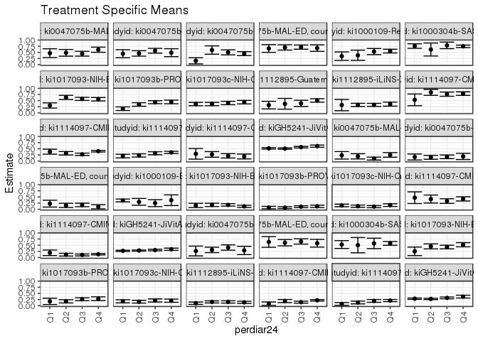

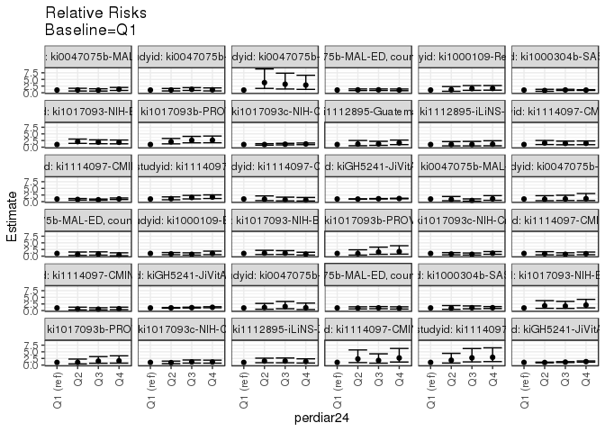

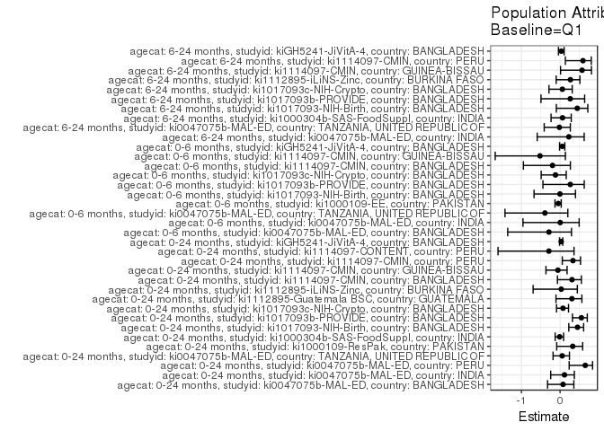

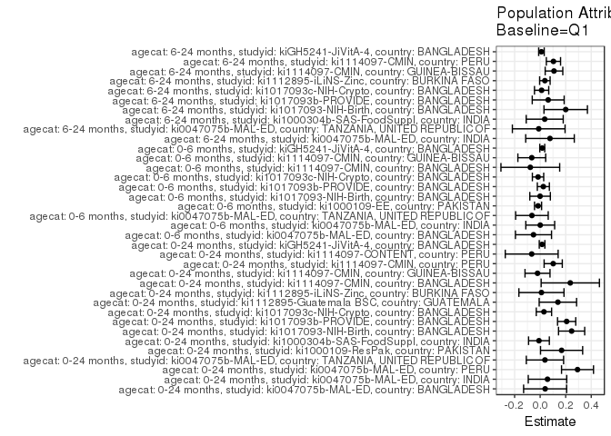

## Results Table

### Parameter: TSM

| agecat | studyid | country | intervention_level | baseline_level | estimate | ci_lower | ci_upper |
| --- | --- | --- | --- | --- | --- | --- | --- |
| 0-24 months | ki0047075b-MAL-ED | BANGLADESH | Q1 | NA | 0.4666667 | 0.2878075 | 0.6455258 |
| 0-24 months | ki0047075b-MAL-ED | BANGLADESH | Q2 | NA | 0.4807692 | 0.3447138 | 0.6168247 |
| 0-24 months | ki0047075b-MAL-ED | BANGLADESH | Q3 | NA | 0.4444444 | 0.3463772 | 0.5425117 |
| 0-24 months | ki0047075b-MAL-ED | BANGLADESH | Q4 | NA | 0.6071429 | 0.5025042 | 0.7117815 |
| 0-24 months | ki0047075b-MAL-ED | INDIA | Q1 | NA | 0.4444444 | 0.2818011 | 0.6070877 |
| 0-24 months | ki0047075b-MAL-ED | INDIA | Q2 | NA | 0.4556962 | 0.3456539 | 0.5657385 |
| 0-24 months | ki0047075b-MAL-ED | INDIA | Q3 | NA | 0.5656566 | 0.4678224 | 0.6634907 |
| 0-24 months | ki0047075b-MAL-ED | INDIA | Q4 | NA | 0.4864865 | 0.3251155 | 0.6478575 |
| 0-24 months | ki0047075b-MAL-ED | PERU | Q1 | NA | 0.1562500 | 0.0302392 | 0.2822608 |
| 0-24 months | ki0047075b-MAL-ED | PERU | Q2 | NA | 0.5937500 | 0.4233030 | 0.7641970 |
| 0-24 months | ki0047075b-MAL-ED | PERU | Q3 | NA | 0.5000000 | 0.3976608 | 0.6023392 |
| 0-24 months | ki0047075b-MAL-ED | PERU | Q4 | NA | 0.4489796 | 0.3684409 | 0.5295183 |
| 0-24 months | ki0047075b-MAL-ED | TANZANIA, UNITED REPUBLIC OF | Q1 | NA | 0.6571429 | 0.4995883 | 0.8146974 |
| 0-24 months | ki0047075b-MAL-ED | TANZANIA, UNITED REPUBLIC OF | Q2 | NA | 0.7000000 | 0.5924429 | 0.8075571 |
| 0-24 months | ki0047075b-MAL-ED | TANZANIA, UNITED REPUBLIC OF | Q3 | NA | 0.7129630 | 0.6274821 | 0.7984439 |
| 0-24 months | ki0047075b-MAL-ED | TANZANIA, UNITED REPUBLIC OF | Q4 | NA | 0.6734694 | 0.5419162 | 0.8050226 |
| 0-24 months | ki1000109-ResPak | PAKISTAN | Q1 | NA | 0.3448276 | 0.1715217 | 0.5181334 |
| 0-24 months | ki1000109-ResPak | PAKISTAN | Q2 | NA | 0.3809524 | 0.1728768 | 0.5890280 |
| 0-24 months | ki1000109-ResPak | PAKISTAN | Q3 | NA | 0.5322581 | 0.4078347 | 0.6566814 |
| 0-24 months | ki1000109-ResPak | PAKISTAN | Q4 | NA | 0.5515152 | 0.4754923 | 0.6275380 |
| 0-24 months | ki1000304b-SAS-FoodSuppl | INDIA | Q1 | NA | 0.7558140 | 0.6649091 | 0.8467188 |
| 0-24 months | ki1000304b-SAS-FoodSuppl | INDIA | Q2 | NA | 0.6153846 | 0.3506058 | 0.8801634 |
| 0-24 months | ki1000304b-SAS-FoodSuppl | INDIA | Q3 | NA | 0.7837838 | 0.6509803 | 0.9165873 |
| 0-24 months | ki1000304b-SAS-FoodSuppl | INDIA | Q4 | NA | 0.7446809 | 0.6937278 | 0.7956339 |
| 0-24 months | ki1017093-NIH-Birth | BANGLADESH | Q1 | NA | 0.3000000 | 0.1925625 | 0.4074375 |
| 0-24 months | ki1017093-NIH-Birth | BANGLADESH | Q2 | NA | 0.6279070 | 0.5444286 | 0.7113853 |
| 0-24 months | ki1017093-NIH-Birth | BANGLADESH | Q3 | NA | 0.5689655 | 0.5051906 | 0.6327405 |
| 0-24 months | ki1017093-NIH-Birth | BANGLADESH | Q4 | NA | 0.5538462 | 0.4840205 | 0.6236718 |
| 0-24 months | ki1017093b-PROVIDE | BANGLADESH | Q1 | NA | 0.1683168 | 0.0952970 | 0.2413366 |
| 0-24 months | ki1017093b-PROVIDE | BANGLADESH | Q2 | NA | 0.3413174 | 0.2693530 | 0.4132817 |

[output cut: 114 more lines]

### Parameter: E(Y)

| agecat | studyid | country | intervention_level | baseline_level | estimate | ci_lower | ci_upper |
| --- | --- | --- | --- | --- | --- | --- | --- |
| 0-24 months | ki0047075b-MAL-ED | BANGLADESH | NA | NA | 0.5056604 | 0.4453505 | 0.5659702 |
| 0-24 months | ki0047075b-MAL-ED | INDIA | NA | NA | 0.5019920 | 0.4400130 | 0.5639710 |
| 0-24 months | ki0047075b-MAL-ED | PERU | NA | NA | 0.4488449 | 0.3927492 | 0.5049406 |
| 0-24 months | ki0047075b-MAL-ED | TANZANIA, UNITED REPUBLIC OF | NA | NA | 0.6946565 | 0.6387828 | 0.7505302 |
| 0-24 months | ki1000109-ResPak | PAKISTAN | NA | NA | 0.5126354 | 0.4536662 | 0.5716045 |
| 0-24 months | ki1000304b-SAS-FoodSuppl | INDIA | NA | NA | 0.7464115 | 0.7046540 | 0.7881689 |
| 0-24 months | ki1017093-NIH-Birth | BANGLADESH | NA | NA | 0.5463259 | 0.5072952 | 0.5853565 |
| 0-24 months | ki1017093b-PROVIDE | BANGLADESH | NA | NA | 0.3757143 | 0.3398113 | 0.4116172 |
| 0-24 months | ki1017093c-NIH-Crypto | BANGLADESH | NA | NA | 0.3878628 | 0.3531521 | 0.4225735 |
| 0-24 months | ki1112895-Guatemala BSC | GUATEMALA | NA | NA | 0.4530744 | 0.3974812 | 0.5086676 |
| 0-24 months | ki1112895-iLiNS-Zinc | BURKINA FASO | NA | NA | 0.3274878 | 0.2607918 | 0.3941837 |
| 0-24 months | ki1114097-CMIN | BANGLADESH | NA | NA | 0.7653430 | 0.7153466 | 0.8153393 |
| 0-24 months | ki1114097-CMIN | GUINEA-BISSAU | NA | NA | 0.3612991 | 0.3368005 | 0.3857976 |
| 0-24 months | ki1114097-CMIN | PERU | NA | NA | 0.3057051 | 0.2760637 | 0.3353464 |
| 0-24 months | ki1114097-CONTENT | PERU | NA | NA | 0.2279070 | 0.1717046 | 0.2841094 |
| 0-24 months | kiGH5241-JiVitA-4 | BANGLADESH | NA | NA | 0.5316060 | 0.5154292 | 0.5477829 |
| 0-6 months | ki0047075b-MAL-ED | BANGLADESH | NA | NA | 0.1811321 | 0.1346751 | 0.2275890 |
| 0-6 months | ki0047075b-MAL-ED | INDIA | NA | NA | 0.1673307 | 0.1210604 | 0.2136010 |
| 0-6 months | ki0047075b-MAL-ED | TANZANIA, UNITED REPUBLIC OF | NA | NA | 0.1641221 | 0.1191873 | 0.2090569 |
| 0-6 months | ki1000109-EE | PAKISTAN | NA | NA | 0.3430079 | 0.2951521 | 0.3908637 |
| 0-6 months | ki1017093-NIH-Birth | BANGLADESH | NA | NA | 0.1565495 | 0.1280614 | 0.1850376 |
| 0-6 months | ki1017093b-PROVIDE | BANGLADESH | NA | NA | 0.0942857 | 0.0726222 | 0.1159492 |
| 0-6 months | ki1017093c-NIH-Crypto | BANGLADESH | NA | NA | 0.1385224 | 0.1139141 | 0.1631308 |
| 0-6 months | ki1114097-CMIN | BANGLADESH | NA | NA | 0.3935018 | 0.3358674 | 0.4511362 |
| 0-6 months | ki1114097-CMIN | GUINEA-BISSAU | NA | NA | 0.1259259 | 0.1047621 | 0.1470897 |
| 0-6 months | kiGH5241-JiVitA-4 | BANGLADESH | NA | NA | 0.2867446 | 0.2729319 | 0.3005573 |
| 6-24 months | ki0047075b-MAL-ED | INDIA | NA | NA | 0.3402062 | 0.2733649 | 0.4070475 |
| 6-24 months | ki0047075b-MAL-ED | TANZANIA, UNITED REPUBLIC OF | NA | NA | 0.6203209 | 0.5505766 | 0.6900651 |
| 6-24 months | ki1000304b-SAS-FoodSuppl | INDIA | NA | NA | 0.5619469 | 0.4971181 | 0.6267757 |
| 6-24 months | ki1017093-NIH-Birth | BANGLADESH | NA | NA | 0.4500000 | 0.4023647 | 0.4976353 |
| 6-24 months | ki1017093b-PROVIDE | BANGLADESH | NA | NA | 0.2394366 | 0.2018814 | 0.2769918 |
| 6-24 months | ki1017093c-NIH-Crypto | BANGLADESH | NA | NA | 0.1887097 | 0.1578857 | 0.2195336 |
| 6-24 months | ki1112895-iLiNS-Zinc | BURKINA FASO | NA | NA | 0.1377778 | 0.1091390 | 0.1664166 |
| 6-24 months | ki1114097-CMIN | GUINEA-BISSAU | NA | NA | 0.1902834 | 0.1683827 | 0.2121841 |
| 6-24 months | ki1114097-CMIN | PERU | NA | NA | 0.1755319 | 0.1483241 | 0.2027397 |
| 6-24 months | kiGH5241-JiVitA-4 | BANGLADESH | NA | NA | 0.2949907 | 0.2786334 | 0.3113480 |

### Parameter: RR

| agecat | studyid | country | intervention_level | baseline_level | estimate | ci_lower | ci_upper |
| --- | --- | --- | --- | --- | --- | --- | --- |
| 0-24 months | ki0047075b-MAL-ED | BANGLADESH | Q1 | Q1 | 1.0000000 | 1.0000000 | 1.0000000 |
| 0-24 months | ki0047075b-MAL-ED | BANGLADESH | Q2 | Q1 | 1.0302198 | 0.6397652 | 1.6589725 |
| 0-24 months | ki0047075b-MAL-ED | BANGLADESH | Q3 | Q1 | 0.9523810 | 0.6119912 | 1.4820956 |
| 0-24 months | ki0047075b-MAL-ED | BANGLADESH | Q4 | Q1 | 1.3010204 | 0.8546291 | 1.9805715 |
| 0-24 months | ki0047075b-MAL-ED | INDIA | Q1 | Q1 | 1.0000000 | 1.0000000 | 1.0000000 |
| 0-24 months | ki0047075b-MAL-ED | INDIA | Q2 | Q1 | 1.0253165 | 0.6613711 | 1.5895371 |
| 0-24 months | ki0047075b-MAL-ED | INDIA | Q3 | Q1 | 1.2727273 | 0.8490824 | 1.9077474 |
| 0-24 months | ki0047075b-MAL-ED | INDIA | Q4 | Q1 | 1.0945946 | 0.6679607 | 1.7937242 |
| 0-24 months | ki0047075b-MAL-ED | PERU | Q1 | Q1 | 1.0000000 | 1.0000000 | 1.0000000 |
| 0-24 months | ki0047075b-MAL-ED | PERU | Q2 | Q1 | 3.7999999 | 1.6143994 | 8.9445024 |
| 0-24 months | ki0047075b-MAL-ED | PERU | Q3 | Q1 | 3.2000000 | 1.3925180 | 7.3535856 |
| 0-24 months | ki0047075b-MAL-ED | PERU | Q4 | Q1 | 2.8734694 | 1.2577720 | 6.5646445 |
| 0-24 months | ki0047075b-MAL-ED | TANZANIA, UNITED REPUBLIC OF | Q1 | Q1 | 1.0000000 | 1.0000000 | 1.0000000 |
| 0-24 months | ki0047075b-MAL-ED | TANZANIA, UNITED REPUBLIC OF | Q2 | Q1 | 1.0652174 | 0.8012448 | 1.4161566 |
| 0-24 months | ki0047075b-MAL-ED | TANZANIA, UNITED REPUBLIC OF | Q3 | Q1 | 1.0849436 | 0.8298288 | 1.4184886 |
| 0-24 months | ki0047075b-MAL-ED | TANZANIA, UNITED REPUBLIC OF | Q4 | Q1 | 1.0248447 | 0.7522281 | 1.3962609 |
| 0-24 months | ki1000109-ResPak | PAKISTAN | Q1 | Q1 | 1.0000000 | 1.0000000 | 1.0000000 |
| 0-24 months | ki1000109-ResPak | PAKISTAN | Q2 | Q1 | 1.1047619 | 0.5259157 | 2.3207120 |
| 0-24 months | ki1000109-ResPak | PAKISTAN | Q3 | Q1 | 1.5435484 | 0.8867358 | 2.6868676 |
| 0-24 months | ki1000109-ResPak | PAKISTAN | Q4 | Q1 | 1.5993939 | 0.9497822 | 2.6933132 |
| 0-24 months | ki1000304b-SAS-FoodSuppl | INDIA | Q1 | Q1 | 1.0000000 | 1.0000000 | 1.0000000 |
| 0-24 months | ki1000304b-SAS-FoodSuppl | INDIA | Q2 | Q1 | 0.8142012 | 0.5208425 | 1.2727908 |
| 0-24 months | ki1000304b-SAS-FoodSuppl | INDIA | Q3 | Q1 | 1.0370062 | 0.8424432 | 1.2765037 |
| 0-24 months | ki1000304b-SAS-FoodSuppl | INDIA | Q4 | Q1 | 0.9852700 | 0.8579461 | 1.1314896 |
| 0-24 months | ki1017093-NIH-Birth | BANGLADESH | Q1 | Q1 | 1.0000000 | 1.0000000 | 1.0000000 |
| 0-24 months | ki1017093-NIH-Birth | BANGLADESH | Q2 | Q1 | 2.0930233 | 1.4284698 | 3.0667407 |
| 0-24 months | ki1017093-NIH-Birth | BANGLADESH | Q3 | Q1 | 1.8965517 | 1.3031452 | 2.7601747 |
| 0-24 months | ki1017093-NIH-Birth | BANGLADESH | Q4 | Q1 | 1.8461538 | 1.2629320 | 2.6987076 |
| 0-24 months | ki1017093b-PROVIDE | BANGLADESH | Q1 | Q1 | 1.0000000 | 1.0000000 | 1.0000000 |
| 0-24 months | ki1017093b-PROVIDE | BANGLADESH | Q2 | Q1 | 2.0278267 | 1.2518453 | 3.2848156 |

[output cut: 114 more lines]

### Parameter: PAR

| agecat | studyid | country | intervention_level | baseline_level | estimate | ci_lower | ci_upper |
| --- | --- | --- | --- | --- | --- | --- | --- |
| 0-24 months | ki0047075b-MAL-ED | BANGLADESH | Q1 | NA | 0.0389937 | -0.1294840 | 0.2074714 |
| 0-24 months | ki0047075b-MAL-ED | INDIA | Q1 | NA | 0.0575476 | -0.0931381 | 0.2082333 |
| 0-24 months | ki0047075b-MAL-ED | PERU | Q1 | NA | 0.2925949 | 0.1674089 | 0.4177809 |
| 0-24 months | ki0047075b-MAL-ED | TANZANIA, UNITED REPUBLIC OF | Q1 | NA | 0.0375136 | -0.1084764 | 0.1835037 |
| 0-24 months | ki1000109-ResPak | PAKISTAN | Q1 | NA | 0.1678078 | 0.0028127 | 0.3328029 |
| 0-24 months | ki1000304b-SAS-FoodSuppl | INDIA | Q1 | NA | -0.0094025 | -0.0906859 | 0.0718810 |
| 0-24 months | ki1017093-NIH-Birth | BANGLADESH | Q1 | NA | 0.2463259 | 0.1439308 | 0.3487209 |
| 0-24 months | ki1017093b-PROVIDE | BANGLADESH | Q1 | NA | 0.2073975 | 0.1361073 | 0.2786876 |
| 0-24 months | ki1017093c-NIH-Crypto | BANGLADESH | Q1 | NA | 0.0295740 | -0.0304318 | 0.0895799 |
| 0-24 months | ki1112895-Guatemala BSC | GUATEMALA | Q1 | NA | 0.1387887 | -0.0076528 | 0.2852303 |
| 0-24 months | ki1112895-iLiNS-Zinc | BURKINA FASO | Q1 | NA | 0.0100816 | -0.1664349 | 0.1865981 |
| 0-24 months | ki1114097-CMIN | BANGLADESH | Q1 | NA | 0.2359312 | 0.0077534 | 0.4641090 |
| 0-24 months | ki1114097-CMIN | GUINEA-BISSAU | Q1 | NA | -0.0207234 | -0.1185442 | 0.0770973 |
| 0-24 months | ki1114097-CMIN | PERU | Q1 | NA | 0.1021652 | 0.0310777 | 0.1732528 |
| 0-24 months | ki1114097-CONTENT | PERU | Q1 | NA | -0.0662107 | -0.2731844 | 0.1407631 |
| 0-24 months | kiGH5241-JiVitA-4 | BANGLADESH | Q1 | NA | 0.0149820 | -0.0070467 | 0.0370107 |
| 0-6 months | ki0047075b-MAL-ED | BANGLADESH | Q1 | NA | -0.0522013 | -0.1934297 | 0.0890272 |
| 0-6 months | ki0047075b-MAL-ED | INDIA | Q1 | NA | 0.0006640 | -0.1122624 | 0.1135904 |
| 0-6 months | ki0047075b-MAL-ED | TANZANIA, UNITED REPUBLIC OF | Q1 | NA | -0.0644493 | -0.1919473 | 0.0630487 |
| 0-6 months | ki1000109-EE | PAKISTAN | Q1 | NA | -0.0164227 | -0.0441060 | 0.0112606 |
| 0-6 months | ki1017093-NIH-Birth | BANGLADESH | Q1 | NA | -0.0005933 | -0.0809898 | 0.0798031 |
| 0-6 months | ki1017093b-PROVIDE | BANGLADESH | Q1 | NA | 0.0249788 | -0.0221082 | 0.0720657 |
| 0-6 months | ki1017093c-NIH-Crypto | BANGLADESH | Q1 | NA | -0.0165578 | -0.0609535 | 0.0278379 |
| 0-6 months | ki1114097-CMIN | BANGLADESH | Q1 | NA | -0.0770864 | -0.3070586 | 0.1528857 |
| 0-6 months | ki1114097-CMIN | GUINEA-BISSAU | Q1 | NA | -0.0655634 | -0.1744455 | 0.0433186 |
| 0-6 months | kiGH5241-JiVitA-4 | BANGLADESH | Q1 | NA | 0.0163723 | -0.0030606 | 0.0358051 |
| 6-24 months | ki0047075b-MAL-ED | INDIA | Q1 | NA | 0.0770483 | -0.1130995 | 0.2671961 |
| 6-24 months | ki0047075b-MAL-ED | TANZANIA, UNITED REPUBLIC OF | Q1 | NA | -0.0112581 | -0.2175369 | 0.1950207 |
| 6-24 months | ki1000304b-SAS-FoodSuppl | INDIA | Q1 | NA | 0.0356311 | -0.1092985 | 0.1805608 |
| 6-24 months | ki1017093-NIH-Birth | BANGLADESH | Q1 | NA | 0.2000000 | 0.0299586 | 0.3700414 |
| 6-24 months | ki1017093b-PROVIDE | BANGLADESH | Q1 | NA | 0.0629660 | -0.0619829 | 0.1879149 |
| 6-24 months | ki1017093c-NIH-Crypto | BANGLADESH | Q1 | NA | 0.0114047 | -0.0444534 | 0.0672628 |
| 6-24 months | ki1112895-iLiNS-Zinc | BURKINA FASO | Q1 | NA | 0.0369374 | -0.0040784 | 0.0779533 |
| 6-24 months | ki1114097-CMIN | GUINEA-BISSAU | Q1 | NA | 0.1083161 | 0.0393688 | 0.1772635 |
| 6-24 months | ki1114097-CMIN | PERU | Q1 | NA | 0.1041033 | 0.0484348 | 0.1597719 |
| 6-24 months | kiGH5241-JiVitA-4 | BANGLADESH | Q1 | NA | 0.0100959 | -0.0116241 | 0.0318159 |

### Parameter: PAF

| agecat | studyid | country | intervention_level | baseline_level | estimate | ci_lower | ci_upper |
| --- | --- | --- | --- | --- | --- | --- | --- |
| 0-24 months | ki0047075b-MAL-ED | BANGLADESH | Q1 | NA | 0.0771144 | -0.3243154 | 0.3568619 |
| 0-24 months | ki0047075b-MAL-ED | INDIA | Q1 | NA | 0.1146384 | -0.2430640 | 0.3694089 |
| 0-24 months | ki0047075b-MAL-ED | PERU | Q1 | NA | 0.6518842 | 0.2358338 | 0.8414159 |
| 0-24 months | ki0047075b-MAL-ED | TANZANIA, UNITED REPUBLIC OF | Q1 | NA | 0.0540031 | -0.1815173 | 0.2425756 |
| 0-24 months | ki1000109-ResPak | PAKISTAN | Q1 | NA | 0.3273434 | -0.0868925 | 0.5837059 |
| 0-24 months | ki1000304b-SAS-FoodSuppl | INDIA | Q1 | NA | -0.0125969 | -0.1275799 | 0.0906609 |
| 0-24 months | ki1017093-NIH-Birth | BANGLADESH | Q1 | NA | 0.4508772 | 0.2262406 | 0.6102976 |
| 0-24 months | ki1017093b-PROVIDE | BANGLADESH | Q1 | NA | 0.5520084 | 0.3209384 | 0.7044503 |
| 0-24 months | ki1017093c-NIH-Crypto | BANGLADESH | Q1 | NA | 0.0762487 | -0.0922004 | 0.2187180 |
| 0-24 months | ki1112895-Guatemala BSC | GUATEMALA | Q1 | NA | 0.3063265 | -0.1059078 | 0.5648978 |
| 0-24 months | ki1112895-iLiNS-Zinc | BURKINA FASO | Q1 | NA | 0.0307847 | -0.6985707 | 0.4469596 |
| 0-24 months | ki1114097-CMIN | BANGLADESH | Q1 | NA | 0.3082686 | -0.0681032 | 0.5520168 |
| 0-24 months | ki1114097-CMIN | GUINEA-BISSAU | Q1 | NA | -0.0573581 | -0.3659345 | 0.1815083 |
| 0-24 months | ki1114097-CMIN | PERU | Q1 | NA | 0.3341954 | 0.0572071 | 0.5298058 |
| 0-24 months | ki1114097-CONTENT | PERU | Q1 | NA | -0.2905162 | -1.6070818 | 0.3611892 |
| 0-24 months | kiGH5241-JiVitA-4 | BANGLADESH | Q1 | NA | 0.0281825 | -0.0142832 | 0.0688702 |
| 0-6 months | ki0047075b-MAL-ED | BANGLADESH | Q1 | NA | -0.2881944 | -1.3568722 | 0.2959122 |
| 0-6 months | ki0047075b-MAL-ED | INDIA | Q1 | NA | 0.0039683 | -0.9612496 | 0.4941596 |
| 0-6 months | ki0047075b-MAL-ED | TANZANIA, UNITED REPUBLIC OF | Q1 | NA | -0.3926910 | -1.4269029 | 0.2007969 |
| 0-6 months | ki1000109-EE | PAKISTAN | Q1 | NA | -0.0478785 | -0.1318035 | 0.0298234 |
| 0-6 months | ki1017093-NIH-Birth | BANGLADESH | Q1 | NA | -0.0037901 | -0.6743017 | 0.3982001 |
| 0-6 months | ki1017093b-PROVIDE | BANGLADESH | Q1 | NA | 0.2649265 | -0.4438667 | 0.6257736 |
| 0-6 months | ki1017093c-NIH-Crypto | BANGLADESH | Q1 | NA | -0.1195314 | -0.4900109 | 0.1588312 |
| 0-6 months | ki1114097-CMIN | BANGLADESH | Q1 | NA | -0.1958985 | -0.9501640 | 0.2666395 |
| 0-6 months | ki1114097-CMIN | GUINEA-BISSAU | Q1 | NA | -0.5206508 | -1.6807759 | 0.1374218 |
| 0-6 months | kiGH5241-JiVitA-4 | BANGLADESH | Q1 | NA | 0.0570970 | -0.0134780 | 0.1227574 |
| 6-24 months | ki0047075b-MAL-ED | INDIA | Q1 | NA | 0.2264753 | -0.5924928 | 0.6242743 |
| 6-24 months | ki0047075b-MAL-ED | TANZANIA, UNITED REPUBLIC OF | Q1 | NA | -0.0181488 | -0.4114372 | 0.2655522 |
| 6-24 months | ki1000304b-SAS-FoodSuppl | INDIA | Q1 | NA | 0.0634065 | -0.2336974 | 0.2889608 |
| 6-24 months | ki1017093-NIH-Birth | BANGLADESH | Q1 | NA | 0.4444444 | -0.0962547 | 0.7184578 |
| 6-24 months | ki1017093b-PROVIDE | BANGLADESH | Q1 | NA | 0.2629758 | -0.4943970 | 0.6365058 |
| 6-24 months | ki1017093c-NIH-Crypto | BANGLADESH | Q1 | NA | 0.0604352 | -0.2873717 | 0.3142758 |
| 6-24 months | ki1112895-iLiNS-Zinc | BURKINA FASO | Q1 | NA | 0.2680943 | -0.1010584 | 0.5134809 |
| 6-24 months | ki1114097-CMIN | GUINEA-BISSAU | Q1 | NA | 0.5692359 | 0.0120035 | 0.8121879 |
| 6-24 months | ki1114097-CMIN | PERU | Q1 | NA | 0.5930736 | 0.1369807 | 0.8081282 |
| 6-24 months | kiGH5241-JiVitA-4 | BANGLADESH | Q1 | NA | 0.0342244 | -0.0423401 | 0.1051650 |